# STAT184 Project

Xuanting Dong & Zhixuan Yang

12/9/2019

### Research Question

#### Which factors can heavily influence the sales of video games.

#### Here we first change all the column names to lower case, which is more reader-friendly.

```r
# clean up workspace environment
rm(list = ls())

# all packages used for the assignment
library(tidyverse)
library(DataComputing)
library(party)
library(dplyr)
library(rpart)
library(rpart.plot)
library(readr)

# user defined functions

#function to read file
file <- function(url){
  file <- read_csv(url)
  return (file)
}

#function to rename the attributes to lower-case
rename_primary <- function(data){
  data <-
    data %>%
    rename(
      name = Name,
      platform = Platform,
      year = Year_of_Release,
      genre = Genre,
      publisher = Publisher,
      na_sales = NA_Sales,
      eu_sales = EU_Sales,
      jp_sales= JP_Sales,
      other_sales = Other_Sales,
      global_sales =  Global_Sales,
      critic_score = Critic_Score,
      critic_count = Critic_Count,
      user_score = User_Score,
      user_count = User_Count,
      rating = Rating
    )
  return (data)
}

#function to rename secondary data
rename_developer <- function(data){
  data <-
    data %>%
    rename(
      name = Name,
      platform = Platform,
      year = Year_of_Release,
      genre = Genre,
      publisher = Publisher,
      rating = Rating,
      developer = Developer
    )
  return (data)
}
```

### Import the Data & Inspections

```r
library(readr)
Primary <- read_csv("Video_Game_Sales_as_of_Jan_2017.csv")
```

```r
head(Primary)
```

| Name | Platform | Year_of_Release | Genre | Publisher | NA_Sales | EU_Sales | JP_Sales | Other_Sales | Global_Sales | Critic_Score | Critic_Count | User_Score | User_Count | Rating |
| --- | --- | --- | --- | --- | --- | --- | --- | --- | --- | --- | --- | --- | --- | --- |
| Wii Sports | Wii | 2006 | Sports | Nintendo | 41.36 | 28.96 | 3.77 | 8.45 | 82.54 | 76 | 51 | 8.0 | 324 | E |
| Super Mario Bros. | NES | 1985 | Platform | Nintendo | 29.08 | 3.58 | 6.81 | 0.77 | 40.24 | NA | NA | NA | NA | NA |
| Mario Kart Wii | Wii | 2008 | Racing | Nintendo | 15.68 | 12.80 | 3.79 | 3.29 | 35.57 | 82 | 73 | 8.3 | 712 | E |
| Wii Sports Resort | Wii | 2009 | Sports | Nintendo | 15.61 | 10.95 | 3.28 | 2.95 | 32.78 | 80 | 73 | 8.0 | 193 | E |
| Pokemon Red/Pokemon Blue | G | 1996 | Role-Playing | Nintendo | 11.27 | 8.89 | 10.22 | 1.00 | 31.37 | NA | NA | NA | NA | NA |
| Tetris | G | 1989 | Puzzle | Nintendo | 23.20 | 2.26 | 4.22 | 0.58 | 30.26 | NA | NA | NA | NA | NA |

```r
Developer <- read_csv("GameDeveloper.csv")
```

```r
head(Developer)
```

| Name | Platform | Year_of_Release | Genre | Publisher | Developer | Rating |
| --- | --- | --- | --- | --- | --- | --- |
| Men of Valor | XB | 2004 | Shooter | Vivendi Games | 2015 | M |
| Ready 2 Rumble Revolution | Wii | 2009 | Sports | Atari | 10tacle Studios | T |
| Secret Files: Tunguska | Wii | 2008 | Adventure | Koch Media | 10tacle Studios, Fusionsphere Systems | T |
| Secret Files: Tunguska | DS | 2008 | Adventure | Deep Silver | 10tacle Studios, Fusionsphere Systems | T |
| IL-2 Sturmovik | PC | 2001 | Simulation | Blue Byte | 1C, 1C Company | T |
| IL-2 Sturmovik: Forgotten Battles | PC | 2003 | Simulation | Ubisoft | 1C, 1C Company | T |

### Change the Column Names to Lower-case

```r
Developer <-
  rename_developer(Developer)
Primary <-
  rename_primary(Primary)
head(Primary)
```

| name | platform | year | genre | publisher | na_sales | eu_sales | jp_sales | other_sales | global_sales | critic_score | critic_count | user_score | user_count | rating |
| --- | --- | --- | --- | --- | --- | --- | --- | --- | --- | --- | --- | --- | --- | --- |
| Wii Sports | Wii | 2006 | Sports | Nintendo | 41.36 | 28.96 | 3.77 | 8.45 | 82.54 | 76 | 51 | 8.0 | 324 | E |
| Super Mario Bros. | NES | 1985 | Platform | Nintendo | 29.08 | 3.58 | 6.81 | 0.77 | 40.24 | NA | NA | NA | NA | NA |
| Mario Kart Wii | Wii | 2008 | Racing | Nintendo | 15.68 | 12.80 | 3.79 | 3.29 | 35.57 | 82 | 73 | 8.3 | 712 | E |
| Wii Sports Resort | Wii | 2009 | Sports | Nintendo | 15.61 | 10.95 | 3.28 | 2.95 | 32.78 | 80 | 73 | 8.0 | 193 | E |
| Pokemon Red/Pokemon Blue | G | 1996 | Role-Playing | Nintendo | 11.27 | 8.89 | 10.22 | 1.00 | 31.37 | NA | NA | NA | NA | NA |
| Tetris | G | 1989 | Puzzle | Nintendo | 23.20 | 2.26 | 4.22 | 0.58 | 30.26 | NA | NA | NA | NA | NA |

```r
head(Developer)
```

| name | platform | year | genre | publisher | developer | rating |
| --- | --- | --- | --- | --- | --- | --- |
| Men of Valor | XB | 2004 | Shooter | Vivendi Games | 2015 | M |
| Ready 2 Rumble Revolution | Wii | 2009 | Sports | Atari | 10tacle Studios | T |
| Secret Files: Tunguska | Wii | 2008 | Adventure | Koch Media | 10tacle Studios, Fusionsphere Systems | T |
| Secret Files: Tunguska | DS | 2008 | Adventure | Deep Silver | 10tacle Studios, Fusionsphere Systems | T |
| IL-2 Sturmovik | PC | 2001 | Simulation | Blue Byte | 1C, 1C Company | T |
| IL-2 Sturmovik: Forgotten Battles | PC | 2003 | Simulation | Ubisoft | 1C, 1C Company | T |

#### We are going to use two different datasets, so it is very important to make sure they can merge with a desired new data set, which requires us to clean those two data set first, making them good to merge later.

### Clean Data and Merge two datasets together

```r
Developer <-
  Developer %>%
  select(name,developer)
Games_final <-
  Primary %>%
  left_join(Developer,by=c("name"="name")) #combine two datasets by name
Games_final <-
  Games_final %>%
  na.omit() %>% #remove all missing values
  distinct() #remove redundant data
head(Games_final)
```

| name | platform | year | genre | publisher | na_sales | eu_sales | jp_sales | other_sales | global_sales | critic_score | critic_count | user_score | user_count | rating | developer |
| --- | --- | --- | --- | --- | --- | --- | --- | --- | --- | --- | --- | --- | --- | --- | --- |
| Wii Sports | Wii | 2006 | Sports | Nintendo | 41.36 | 28.96 | 3.77 | 8.45 | 82.54 | 76 | 51 | 8.0 | 324 | E | Nintendo |
| Mario Kart Wii | Wii | 2008 | Racing | Nintendo | 15.68 | 12.80 | 3.79 | 3.29 | 35.57 | 82 | 73 | 8.3 | 712 | E | Nintendo |
| Wii Sports Resort | Wii | 2009 | Sports | Nintendo | 15.61 | 10.95 | 3.28 | 2.95 | 32.78 | 80 | 73 | 8.0 | 193 | E | Nintendo |
| New Super Mario Bros. | DS | 2006 | Platform | Nintendo | 11.28 | 9.15 | 6.50 | 2.88 | 29.81 | 89 | 65 | 8.5 | 433 | E | Nintendo |
| Wii Play | Wii | 2006 | Misc | Nintendo | 13.96 | 9.18 | 2.93 | 2.84 | 28.92 | 58 | 41 | 6.6 | 129 | E | Nintendo |
| New Super Mario Bros. Wii | Wii | 2009 | Platform | Nintendo | 14.48 | 6.95 | 4.70 | 2.25 | 28.38 | 87 | 80 | 8.4 | 595 | E | Nintendo |

#### For doing any analysis, data visualization is necessary. Here we used the merged data to identify the relationship between sales and year because we think the term of years is an important factor that will influence the sales of video games. Meanwhile, we want to know the change in video game marketing in the past 20 years.

### Data Visualization

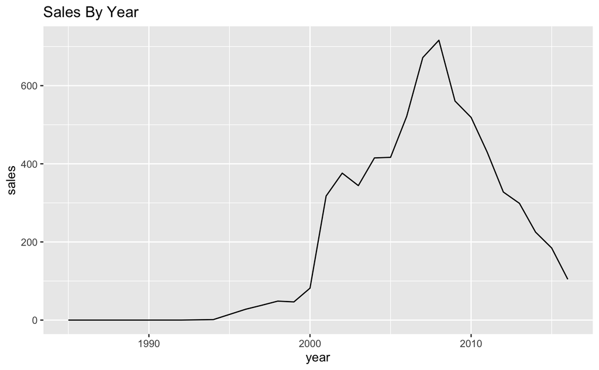

```r
SalesByYear <-
  Games_final %>%
  group_by(year) %>% #group by year to count sales by year
  summarise(total = sum(global_sales)) %>% #sum of the sales
  arrange((year))
SalesByYear %>%
  ggplot(aes(x = year, y = total)) +
  ggtitle("Sales By Year") +
  geom_line() +
  ylab("sales")
```

### Then, after taking year into account, we think the platform for video games is crucial also. We choose to use histogram to display the sales on differernt platforms.

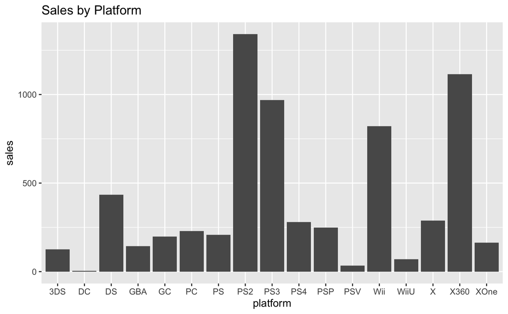

```r
SalesByPlatform <-
  Games_final %>%
  group_by(platform) %>% #group by platform to count platform
  summarise(total=sum(global_sales))
SalesByPlatform %>%
  ggplot(aes(x = platform)) +
  ggtitle("Sales by Platform") +
  geom_bar(aes(weight = total)) + #set up the y-axis as sales
  ylab("sales")
```

#### Obviously, we can see the video games on PS2, PS3, Wii, and X360 have leading sales among all the platforms. Actually, I own an X360, and I think it is a good platform to play because it is connected, globally, and well-designed platforms. Thus, as a customer, we prefer to choose a good platform first, and then to choose the games on the platform. Thus, the success of PS2, PS3, Wii, and X360 also brings the success of those video games published on them.

### Now, we are using basic machine learning to help us find out which factors can heavily influence the sales of video games.

```r
Sales_critic_score_user_score <-
  party::ctree(
    global_sales ~ critic_score + user_score, #find the factors of global sales, and we are interested in user scores and critic scores.
    data=Games_final)
Games_final %>%
  mutate(probability=as.numeric(predict(Sales_critic_score_user_score)),
         likelihood =
           ifelse(global_sales,
                  probability,
                  1-probability)) %>%
  summarise(log_likelihood = sum(log(likelihood)))
```

| log_likelihood |
| --- |
| -3817.967 |

```r
Sales_user_score <-
  party::ctree(
    global_sales ~ user_score, #find the factors of global sales, and we are interested in user scores
    data = Games_final)
Games_final %>%
  mutate(probability=as.numeric(predict(Sales_user_score)),
         likelihood =
           ifelse(global_sales,
                  probability,
                  1-probability)) %>%
  summarise(log_likelihood = sum(log(likelihood)))
```

| log_likelihood |
| --- |
| -2238.192 |

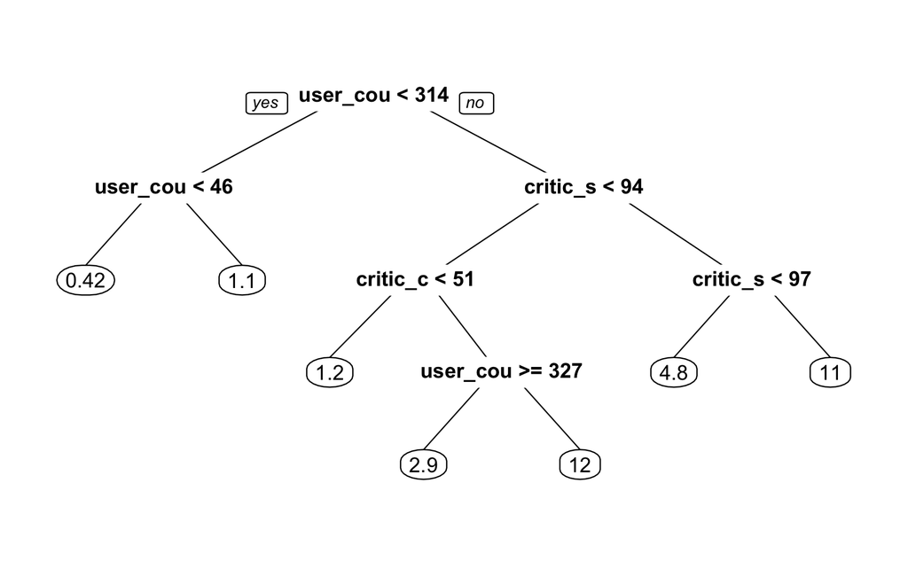

```r
DecisionTree <- rpart( global_sales ~ critic_score + critic_count + user_score + user_count, data = Games_final) #try to build the model that involves critic_score, critic_count, user_score, and user_count.
prp(DecisionTree) #print the decision tree
```

#### From this decision tree, we can see that user_count is the most important factor. Obviously, there is a positive correlation between game sales and the number of user reviews.

### In order to have a more comprehensive view, we decide to make a plot like this, including year, genre, and ranking, which we believe in finding some interesting results.

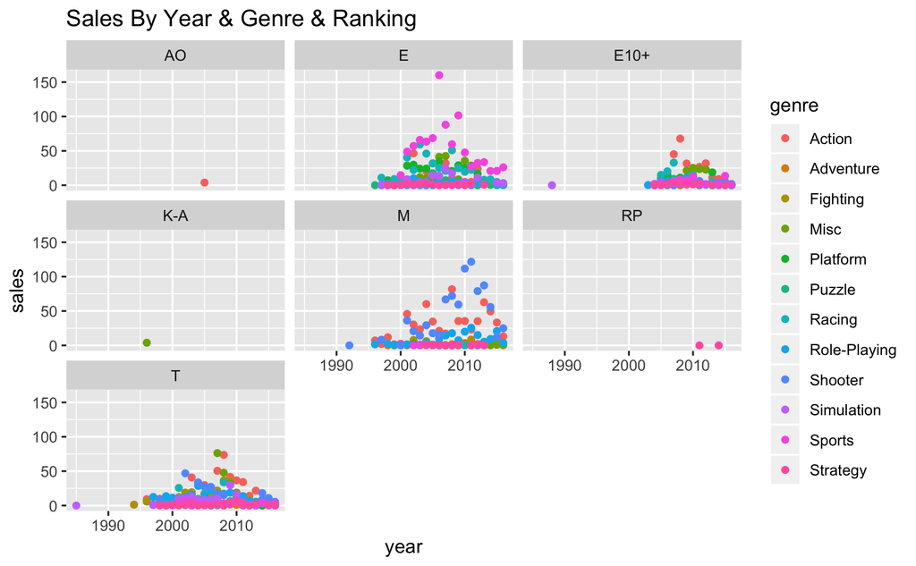

```r
Sales_By_Year_Genre_Ranking <-
  Games_final %>%
  group_by(genre,rating,year) %>% #group by genere, rating, and year
  summarise(total = sum(global_sales)) #sum all the sales
Sales_By_Year_Genre_Ranking %>%
  ggplot(aes(x = year,y = total)) +
  geom_point(aes(color = genre)) +
  ggtitle("Sales By Year & Genre & Ranking") +
  facet_wrap(~rating) + #use facet_wrap to display different rankings.
  ylab("sales")
```

#### This shows that if you want to do the best selling video games, you may have to make it an E level, which requires a high-standard quality level. Other than that, we found that people were more likely to play sports games, like 2K, FIFA. Unluckily, even the E level, sports games in recent five years, the sales were far less than in 2008.

### Lastly, we show the histogram of sales by the top 7 developers. We want to find out which developer’s style is more popular, enabling us to have the right direction in designing our own games.

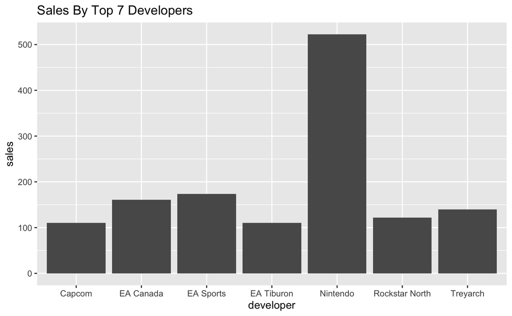

```r
SalesByDeveloper <-
  Games_final %>%
  group_by(developer) %>% #group by developer
  summarise(total = sum(global_sales)) %>%
  arrange(desc(total)) %>% #Sales_user_score
  head(7) #select the top 7 header
SalesByDeveloper %>%
  ggplot(aes(x = developer)) +
  geom_bar(aes(weight = total)) +
  ggtitle("Sales By Top 7 Developers") +
  ylab("sales")
```

#### Unsurprisingly, the games developed by Nintendo were the most popular. Honestly, I play games from Nintendo since I was 10. Some games like Mario are still very popular now.

### Overall, to answer our research question, we made the following conclusion. Ranking, genre, and developer of a video game make a difference in the sale of video games. Games, which are E ranking, genre sports, and developed by Nintendo, will have the best selling.